# Melbourne_Biodiversity

Biodiversity in Melbourne's parks

**Authored by:** Francis Rusli

**Date:** April 2024

**Duration:** 90 mins

**Level:** Intermediate

**Pre-requisite Skills:** Python, basic machine learning, *Optional* Google Collaborate access

*Dataset 1:* Bat Records in Fitzroy Gardens and Royal Botanic Gardens 2010  
[Dataset Link](https://data.melbourne.vic.gov.au/explore/dataset/bat-records-in-fitzroy-gardens-and-royal-botanic-gardens-2010/table/)  
[Metadata Link](https://data.melbourne.vic.gov.au/api/explore/v2.1/catalog/datasets/bat-records-in-fitzroy-gardens-and-royal-botanic-gardens-2010/exports/xlsx?lang=en&timezone=Australia%2FSydney&use_labels=true)

*Dataset 2:* Butterfly biodiversity survey 2017  
[Dataset Link](https://data.melbourne.vic.gov.au/explore/dataset/butterfly-biodiversity-survey-2017/table/)  
[Metadata Link](https://data.melbourne.vic.gov.au/api/explore/v2.1/catalog/datasets/butterfly-biodiversity-survey-2017/exports/xlsx?lang=en&timezone=Australia%2FSydney&use_labels=true)

*Dataset 3:* Bioblitz 2016  
[Dataset Link](https://data.melbourne.vic.gov.au/explore/dataset/bioblitz-2016/table/)  
[Metadata Link](https://data.melbourne.vic.gov.au/api/explore/v2.1/catalog/datasets/bioblitz-2016/exports/csv?lang=en&timezone=Australia%2FSydney&use_labels=true&delimiter=%2C)

**User Story**

*"As a city council member, I want to study and monitor the biodiversity in Melbourne's parks and green spaces, specifically focusing on bats and butterflies while also incorporating other animal species. This information can empower City of Melbourne(CoM) in making conservation planning, address environmental challenges, and foster the natural habitats inside our city limits."*

**Objective**

The 'Urban Biodiversity Monitoring' project is a comprehensive initiative, spanning a dedicated investigation period of 6 weeks, focused on the parks and green spaces of Melbourne. This project is specifically tailored to study and monitor the populations of bats and butterflies, two critical indicators of the ecological health in urban environments.

**Part 1** includes set up, fetching or loading datasets, pre-processing, data cleaning, saving datasets, and merging datasets.

**Part 2** contains an overview analysis of data structures, population spread and biodiversity of species.

**Overview**

The biodiversity within the City of Melbourne's parks and green spaces, especially the populations of bats and butterflies, can significantly reflect the health and balance of our urban ecosystem. This project aims to investigate the population spread, habitat viability, and the interaction of these species with urban development.

**Benefits**

1. **Environmental Health and Ecosystem Balance Assessment:** By monitoring the populations of bats and butterflies, we can gain insights into the overall health of the ecosystem in Melbourne's parks. These species are often considered indicator species[1], meaning changes in their populations can signal changes in the broader environmental conditions. For instance, bats play a crucial role in controlling insect populations and pollinating plants[2], while butterflies are indicators of ecological diversity and health. Studying these populations helps in understanding the impacts of urban development on natural habitats and the effectiveness of current conservation strategies.
2. **Informed Conservation and Urban Planning:** The data gathered will be crucial in guiding conservation efforts and urban planning decisions. Understanding where and how these species thrive can inform the development of green spaces that support biodiversity. This can lead to the creation of urban environments that are not only beneficial for wildlife but also enhance the quality of life for city residents. For example, identifying key habitats and migration patterns of these species can aid in designing parks and green corridors that promote their conservation.
3. **Public Engagement and Education:** This research can also play a significant role in public education and engagement. By raising awareness about the importance of biodiversity in urban areas, We can foster a greater appreciation and understanding among the public. This can lead to increased community involvement in conservation efforts and sustainable practices[5]. Moreover, it can help in promoting citizen science initiatives, where locals can contribute to data collection and monitoring, further expanding the scope and impact of your research.

**Research**

This research project focuses on assessing the biodiversity in Melbourne's parks, with a special emphasis on the populations of bats and butterflies. The aim is to analyze how these species interact with urban development and their spread across different locations and times. The findings will be crucial for informing conservation planning and understanding the health of the urban ecosystem.

Part 1 (First 3 Weeks): Utilizing Python and Jupyter Notebook, the initial stage involves setting up, data cleaning, and preprocessing, followed by a basic analysis focusing on species, locations, and times. The outcome will be an initial understanding of the distribution of bats and butterflies in Melbourne's parks.

Part 2 (Next 3 Weeks): This phase dives into detailed trend analysis and mapping. It aims to uncover patterns in the distribution of these species, hypothesize the reasons for their specific locations, and understand the impact of urban environments on them. The project concludes with strategic recommendations for biodiversity conservation and urban planning.

**Conclusion**

In this analysis, we explored comprehensive datasets concerning bat and butterfly populations within Melbourne's parks. Our focus was on accurately capturing the distribution and prevalence of these species to support ongoing environmental monitoring and conservation initiatives. Through various visualizations, including histograms, pie charts, and interactive maps, we provided a clear and engaging representation of the data. These visualizations highlight the spatial distribution of different species across multiple locations, offering insights into their habitat preferences and population densities.

This study not only aids in understanding the current status of bat and butterfly populations in Melbourne but also serves as a crucial tool for policymakers and conservationists. By identifying trends and potential areas of concern, conservation efforts can be better directed to preserve the biodiversity within these urban green spaces. Future analyses may expand on this by incorporating additional environmental variables, which will further enhance our understanding and facilitate more effective conservation strategies.

## References

[[1]](https://www.ncbi.nlm.nih.gov/pmc/articles/PMC8427576/) Environmental controls on butterfly occurrence and species richness in Israel: The importance of temperature over rainfall

[[2]](https://www.sciencedirect.com/science/article/abs/pii/S2212041621000383) Insectivorous bats provide significant economic value to the Australian cotton industry

[[3]](https://onlinelibrary.wiley.com/doi/abs/10.1111/emr.12120) The effects of light and noise from urban development on biodiversity: Implications for protected areas in Australia

[[4]](https://academic.oup.com/bioscience/article/67/9/799/4056044) Biodiversity in the City: Fundamental Questions for Understanding the Ecology of Urban Green Spaces for Biodiversity Conservation

[[5]](https://link.springer.com/article/10.1007/s10841-009-9252-z) Butterfly conservation in Australia: the importance of community participation

# Part 1 (Set up & Pre-processing)

- Set Up
- Pre-processing

## Part 1.1: Set Up

- Import Core Libraries
- Import Dependencies

```python
##### Install packages
!pip install osmnx
!pip install tqdm
```

```python
#Import core libraries
import requests
import pandas as pd
import numpy as np
import os

import seaborn as sns
import matplotlib.pyplot as plt
import json

import ipywidgets as widgets
from ipywidgets import interact

import osmnx as ox
import geopandas as gpd
import networkx as nx

from sklearn.preprocessing import LabelEncoder
from sklearn.model_selection import train_test_split
from sklearn.ensemble import RandomForestRegressor
from sklearn.metrics import mean_squared_error, r2_score
from sklearn.preprocessing import StandardScaler

import warnings
warnings.filterwarnings("ignore")
```

```python
# Define the company colors format for matplotlib
dark_theme_colors = ['#08af64', '#14a38e', '#0f9295', '#056b8a', '#121212'] #Dark theme
light_theme_colors = ['#2af598', '#22e4ac', '#1bd7bb', '#14c9cb', '#0fbed8', '#08b3e5'] #Light theme
```

```python
def fetch_data(base_url, dataset, api_key, num_records=99, offset=0):
    all_records = []
    max_offset = 9900

    while True:
        if offset > max_offset:
            break

        filters = f'{dataset}/records?limit={num_records}&offset={offset}'
        url = f'{base_url}{filters}&api_key={api_key}'

        try:
            result = requests.get(url, timeout = 10)
            result.raise_for_status()
            records = result.json().get('results')
        except requests.exceptions.RequestException as e:
            raise Exception(f'API request failed: {e}')
        if records is None:
            break
        all_records.extend(records)
        if len(records) < num_records:
            break

        offset += num_records

    df = pd.DataFrame(all_records)
    return df

BASE_URL = 'https://data.melbourne.vic.gov.au/api/explore/v2.1/catalog/datasets/'
API_KEY = ''
```

## Part 1.2: Pre-Processing

#### Dataset 1: Bat records in fitzroy gardens and royal botanic gardens 2010

- Dataset Identifier: bat-records-in-fitzroy-gardens-and-royal-botanic-gardens-2010

[Dataset Link](https://data.melbourne.vic.gov.au/explore/dataset/bat-records-in-fitzroy-gardens-and-royal-botanic-gardens-2010/table/)

**Summary:** This dataset provides detailed observations of various bat species within Fitzroy Gardens and Royal Botanic Gardens over the year 2010. It includes taxonomic classification, common names, and exact locations within the parks.

This dataset includes observations of bats categorized by taxa, genus, and species with specific geo-spatial information, indicating precise observation spots within the parks. The data also lists common names alongside the scientific taxonomy to assist in species identification.

Note: Each observation is pinpointed with latitude and longitude coordinates, providing exact locations but not the area affected or the size of the bat populations.

Note: This dataset is crucial for ecological monitoring and conservation efforts, helping track bat populations and distribution within urban parklands.

```python
SENSOR_DATASET = 'bat-records-in-fitzroy-gardens-and-royal-botanic-gardens-2010'
bat = fetch_data(BASE_URL, SENSOR_DATASET, API_KEY)
bat.head()
```

|  | taxa | kingdom | phylum | class | order | family | genus | species | common_name | park_name | location |
| --- | --- | --- | --- | --- | --- | --- | --- | --- | --- | --- | --- |
| 0 | Mammal | ANIMALIA | CHORDATA | MAMMALIA | CHIROPTERA | MOLOSSIDAE | Mormopterus | None | None | Royal Botanic Gardens | {'lon': 144.9804, 'lat': -37.8312} |
| 1 | Mammal | ANIMALIA | CHORDATA | MAMMALIA | CHIROPTERA | VESPERTILIONIDAE | Chalinolobus | gouldii | Gould's Wattled Bat | Fitzroy Gardens | {'lon': 144.9786, 'lat': -37.8135} |
| 2 | Mammal | ANIMALIA | CHORDATA | MAMMALIA | CHIROPTERA | VESPERTILIONIDAE | Chalinolobus | gouldii | Gould's Wattled Bat | Royal Botanic Gardens | {'lon': 144.9804, 'lat': -37.8312} |
| 3 | Mammal | ANIMALIA | CHORDATA | MAMMALIA | CHIROPTERA | MOLOSSIDAE | Austronomous | australis | White-striped Freetail Bat | Fitzroy Gardens | {'lon': 144.9786, 'lat': -37.8135} |
| 4 | Mammal | ANIMALIA | CHORDATA | MAMMALIA | CHIROPTERA | MOLOSSIDAE | Mormopterus | None | None | Fitzroy Gardens | {'lon': 144.9786, 'lat': -37.8135} |

```python
#View info of data
bat.info()
```

```
<class 'pandas.core.frame.DataFrame'>
RangeIndex: 10 entries, 0 to 9
Data columns (total 11 columns):
 #   Column       Non-Null Count  Dtype
---  ------       --------------  -----
 0   taxa         10 non-null     object
 1   kingdom      10 non-null     object
 2   phylum       10 non-null     object
 3   class        10 non-null     object
 4   order        10 non-null     object
 5   family       10 non-null     object
 6   genus        10 non-null     object
 7   species      5 non-null      object
 8   common_name  5 non-null      object
 9   park_name    10 non-null     object
 10  location     10 non-null     object
dtypes: object(11)
memory usage: 1012.0+ bytes
```

```python
# Check missing values for dataset
missing_values = bat.isnull().sum()
missing_values # Number of missing values in each column
```

```
taxa           0
kingdom        0
phylum         0
class          0
order          0
family         0
genus          0
species        5
common_name    5
park_name      0
location       0
dtype: int64
```

```python
# Column names to check for missing values
column_name_species = 'species'
column_name_common_name = 'common_name'

# Calculate the percentage of missing values
percentage_missing_species = (missing_values[column_name_species] / len(bat)) * 100
percentage_missing_common_name = (missing_values[column_name_common_name] / len(bat)) * 100

# Print the results
print(f"Percentage of missing values for '{column_name_species}': {percentage_missing_species:.2f}%")
print(f"Percentage of missing values for '{column_name_common_name}': {percentage_missing_common_name:.2f}%")
```

```
Percentage of missing values for 'species': 50.00%
Percentage of missing values for 'common_name': 50.00%
```

# Cleaning bat dataset

```python
# Checking and filling missing values if the columns exist
if 'Species' in bat.columns:
    bat['Species'] = bat['Species'].replace('Unknown', np.nan)
if 'Common Name' in bat.columns:
    bat['Common Name'] = bat['Common Name'].replace('Unknown', np.nan)

# Displaying the cleaned data information and the first few rows
print(bat.info())
print(bat.head())
```

```
<class 'pandas.core.frame.DataFrame'>
RangeIndex: 10 entries, 0 to 9
Data columns (total 11 columns):
 #   Column       Non-Null Count  Dtype
---  ------       --------------  -----
 0   taxa         10 non-null     object
 1   kingdom      10 non-null     object
 2   phylum       10 non-null     object
 3   class        10 non-null     object
 4   order        10 non-null     object
 5   family       10 non-null     object
 6   genus        10 non-null     object
 7   species      5 non-null      object
 8   common_name  5 non-null      object
 9   park_name    10 non-null     object
 10  location     10 non-null     object
dtypes: object(11)
memory usage: 1012.0+ bytes
None
     taxa   kingdom    phylum     class       order            family  \
0  Mammal  ANIMALIA  CHORDATA  MAMMALIA  CHIROPTERA        MOLOSSIDAE
1  Mammal  ANIMALIA  CHORDATA  MAMMALIA  CHIROPTERA  VESPERTILIONIDAE
2  Mammal  ANIMALIA  CHORDATA  MAMMALIA  CHIROPTERA  VESPERTILIONIDAE
3  Mammal  ANIMALIA  CHORDATA  MAMMALIA  CHIROPTERA        MOLOSSIDAE
4  Mammal  ANIMALIA  CHORDATA  MAMMALIA  CHIROPTERA        MOLOSSIDAE

          genus    species                 common_name              park_name  \
0   Mormopterus       None                        None  Royal Botanic Gardens
1  Chalinolobus    gouldii         Gould's Wattled Bat        Fitzroy Gardens
2  Chalinolobus    gouldii         Gould's Wattled Bat  Royal Botanic Gardens
3  Austronomous  australis  White-striped Freetail Bat        Fitzroy Gardens
4   Mormopterus       None                        None        Fitzroy Gardens

                             location
0  {'lon': 144.9804, 'lat': -37.8312}
1  {'lon': 144.9786, 'lat': -37.8135}
2  {'lon': 144.9804, 'lat': -37.8312}
3  {'lon': 144.9786, 'lat': -37.8135}
4  {'lon': 144.9786, 'lat': -37.8135}
```

```python
# Print the column names to verify the correct column exists
print(bat.columns)
```

```
Index(['taxa', 'kingdom', 'phylum', 'class', 'order', 'family', 'genus',
       'species', 'common_name', 'park_name', 'location'],
      dtype='object')
```

# Matching column names for data merge

```python
# Renaming the 'location' column to 'geopoint'
bat.rename(columns={'location': 'geopoint'}, inplace=True)

# Displaying the cleaned data information and the first few rows
print(bat.info())
print(bat.head())
```

```
<class 'pandas.core.frame.DataFrame'>
RangeIndex: 10 entries, 0 to 9
Data columns (total 11 columns):
 #   Column       Non-Null Count  Dtype
---  ------       --------------  -----
 0   taxa         10 non-null     object
 1   kingdom      10 non-null     object
 2   phylum       10 non-null     object
 3   class        10 non-null     object
 4   order        10 non-null     object
 5   family       10 non-null     object
 6   genus        10 non-null     object
 7   species      5 non-null      object
 8   common_name  5 non-null      object
 9   park_name    10 non-null     object
 10  geopoint     10 non-null     object
dtypes: object(11)
memory usage: 1012.0+ bytes
None
     taxa   kingdom    phylum     class       order            family  \
0  Mammal  ANIMALIA  CHORDATA  MAMMALIA  CHIROPTERA        MOLOSSIDAE
1  Mammal  ANIMALIA  CHORDATA  MAMMALIA  CHIROPTERA  VESPERTILIONIDAE
2  Mammal  ANIMALIA  CHORDATA  MAMMALIA  CHIROPTERA  VESPERTILIONIDAE
3  Mammal  ANIMALIA  CHORDATA  MAMMALIA  CHIROPTERA        MOLOSSIDAE
4  Mammal  ANIMALIA  CHORDATA  MAMMALIA  CHIROPTERA        MOLOSSIDAE

          genus    species                 common_name              park_name  \
0   Mormopterus       None                        None  Royal Botanic Gardens
1  Chalinolobus    gouldii         Gould's Wattled Bat        Fitzroy Gardens
2  Chalinolobus    gouldii         Gould's Wattled Bat  Royal Botanic Gardens
3  Austronomous  australis  White-striped Freetail Bat        Fitzroy Gardens
4   Mormopterus       None                        None        Fitzroy Gardens

                             geopoint
0  {'lon': 144.9804, 'lat': -37.8312}
1  {'lon': 144.9786, 'lat': -37.8135}
2  {'lon': 144.9804, 'lat': -37.8312}
3  {'lon': 144.9786, 'lat': -37.8135}
4  {'lon': 144.9786, 'lat': -37.8135}
```

#### Dataset 2: Butterfly biodiversity survey 2017

- Dataset Identifier: butterfly-biodiversity-survey-2017

[Dataset Link](https://data.melbourne.vic.gov.au/explore/dataset/butterfly-biodiversity-survey-2017/table/)

**Summary:** Comprehensive survey data capturing observations of butterflies across various sites within Melbourne for the year 2017. Details include environmental conditions, vegetation types, and specific butterfly sightings.

The dataset provides granular details such as temperature, humidity, vegetation details, and wind conditions at the time of each observation, along with precise geographic coordinates. It aims to aid research into butterfly populations and their responses to urban environments.

Note: Data points include specific environmental conditions and butterfly species observations to better understand the impact of urban settings on biodiversity.

Note: The dataset is useful for ecological research and conservation planning, providing essential data for studies on biodiversity in urban parks.

```python
SENSOR_DATASET = 'butterfly-biodiversity-survey-2017'
butterfly = fetch_data(BASE_URL, SENSOR_DATASET, API_KEY)
butterfly.head()
```

|  | site | sloc | walk | date | time | vegwalktime | vegspecies | vegfamily | lat | lon | ... | tabe | brow | csem | aand | jvil | paur | ogyr | gmac | datetime | location |
| --- | --- | --- | --- | --- | --- | --- | --- | --- | --- | --- | --- | --- | --- | --- | --- | --- | --- | --- | --- | --- | --- |
| 0 | Womens Peace Gardens | 2 | 1 | 2017-02-26 | 0001-01-01T11:42:00+00:00 | 1.3128 | Schinus molle | Anacardiaceae | -37.7912 | 144.9244 | ... | 0 | 0 | 0 | 0 | 0 | 0 | 0 | 0 | 2017-02-26T11:42:00+00:00 | {'lon': 144.9244, 'lat': -37.7912} |
| 1 | Argyle Square | 1 | 1 | 2017-11-02 | 0001-01-01T10:30:00+00:00 | 0.3051 | Rosmarinus officinalis | Lamiaceae | -37.8023 | 144.9665 | ... | 0 | 0 | 0 | 0 | 0 | 0 | 0 | 0 | 2017-02-11T10:30:00+00:00 | {'lon': 144.9665, 'lat': -37.8023} |
| 2 | Argyle Square | 2 | 1 | 2017-12-01 | 0001-01-01T10:35:00+00:00 | 0.3620 | Euphorbia sp. | Euphorbiaceae | -37.8026 | 144.9665 | ... | 0 | 0 | 0 | 0 | 0 | 0 | 0 | 0 | 2017-01-12T10:35:00+00:00 | {'lon': 144.9665, 'lat': -37.8026} |
| 3 | Westgate Park | 4 | 1 | 2017-03-03 | 0001-01-01T11:44:00+00:00 | 3.1585 | Melaleuca lanceolata | Myrtaceae | -37.8316 | 144.9089 | ... | 0 | 0 | 0 | 0 | 0 | 0 | 0 | 0 | 2017-03-03T11:44:00+00:00 | {'lon': 144.9089, 'lat': -37.8316} |
| 4 | Argyle Square | 1 | 3 | 2017-01-15 | 0001-01-01T12:33:00+00:00 | 0.4432 | Mentha sp. | Lamiaceae | -37.8027 | 144.9662 | ... | 0 | 0 | 0 | 0 | 0 | 0 | 0 | 0 | 2017-01-15T12:33:00+00:00 | {'lon': 144.9662, 'lat': -37.8027} |

5 rows × 42 columns

```python
#View info of data
butterfly.info()
```

```
<class 'pandas.core.frame.DataFrame'>
RangeIndex: 4056 entries, 0 to 4055
Data columns (total 42 columns):
 #   Column       Non-Null Count  Dtype
---  ------       --------------  -----
 0   site         4056 non-null   object
 1   sloc         4056 non-null   int64
 2   walk         4056 non-null   int64
 3   date         4056 non-null   object
 4   time         4056 non-null   object
 5   vegwalktime  4052 non-null   float64
 6   vegspecies   4056 non-null   object
 7   vegfamily    4056 non-null   object
 8   lat          4056 non-null   float64
 9   lon          4056 non-null   float64
```

[output cut: 34 more lines]

```python
# Check missing values for dataset
missing_values = butterfly.isnull().sum()
missing_values # Number of missing values in each column
```

```
site           0
sloc           0
walk           0
date           0
time           0
vegwalktime    4
vegspecies     0
vegfamily      0
lat            0
lon            0
temp           0
hum            0
win1           0
win2           0
win3           0
win4           0
win            0
per            0
sur            0
prap           0
vker           0
vite           0
blue           0
dpet           0
dple           0
pana           0
pdem           0
hesp           0
esmi           0
cato           0
gaca           0
belo           0
tabe           0
brow           0
csem           0
aand           0
jvil           0
paur           0
ogyr           0
gmac           0
datetime       0
location       0
dtype: int64
```

# Matching columns for merging data

```python
# Renaming columns for consistency
butterfly = butterfly.rename(columns={
    'date': 'sighting_date',
    'lat': 'latitude',
    'lon': 'longitude',
    'location': 'geopoint'
})

# Converting 'datetime' column to datetime type and extracting the time part
butterfly['datetime'] = pd.to_datetime(butterfly['datetime'])
butterfly['time'] = butterfly['datetime'].dt.time

# Updating the 'geopoint' column to ensure correct format
butterfly['geopoint'] = butterfly.apply(
    lambda row: f"{row['latitude']}, {row['longitude']}", axis=1
)

# Display the first few rows of the cleaned dataset
butterfly.head()
```

|  | site | sloc | walk | sighting_date | time | vegwalktime | vegspecies | vegfamily | latitude | longitude | ... | tabe | brow | csem | aand | jvil | paur | ogyr | gmac | datetime | geopoint |
| --- | --- | --- | --- | --- | --- | --- | --- | --- | --- | --- | --- | --- | --- | --- | --- | --- | --- | --- | --- | --- | --- |
| 0 | Womens Peace Gardens | 2 | 1 | 2017-02-26 | 11:42:00 | 1.3128 | Schinus molle | Anacardiaceae | -37.7912 | 144.9244 | ... | 0 | 0 | 0 | 0 | 0 | 0 | 0 | 0 | 2017-02-26 11:42:00+00:00 | -37.7912, 144.9244 |
| 1 | Argyle Square | 1 | 1 | 2017-11-02 | 10:30:00 | 0.3051 | Rosmarinus officinalis | Lamiaceae | -37.8023 | 144.9665 | ... | 0 | 0 | 0 | 0 | 0 | 0 | 0 | 0 | 2017-02-11 10:30:00+00:00 | -37.8023, 144.9665 |
| 2 | Argyle Square | 2 | 1 | 2017-12-01 | 10:35:00 | 0.3620 | Euphorbia sp. | Euphorbiaceae | -37.8026 | 144.9665 | ... | 0 | 0 | 0 | 0 | 0 | 0 | 0 | 0 | 2017-01-12 10:35:00+00:00 | -37.8026, 144.9665 |
| 3 | Westgate Park | 4 | 1 | 2017-03-03 | 11:44:00 | 3.1585 | Melaleuca lanceolata | Myrtaceae | -37.8316 | 144.9089 | ... | 0 | 0 | 0 | 0 | 0 | 0 | 0 | 0 | 2017-03-03 11:44:00+00:00 | -37.8316, 144.9089 |
| 4 | Argyle Square | 1 | 3 | 2017-01-15 | 12:33:00 | 0.4432 | Mentha sp. | Lamiaceae | -37.8027 | 144.9662 | ... | 0 | 0 | 0 | 0 | 0 | 0 | 0 | 0 | 2017-01-15 12:33:00+00:00 | -37.8027, 144.9662 |

5 rows × 42 columns

#### Dataset 3: Bioblitz 2016

- Dataset Identifier: bioblitz-2016

[Dataset Link](https://data.melbourne.vic.gov.au/explore/dataset/bioblitz-2016/table/)

**Summary:** This dataset records a variety of living organisms spotted during the BioBlitz event in Melbourne in 2016. It catalogues diverse species ranging from molluscs to annelids and includes detailed taxonomic information.

Data entries are detailed with the taxonomy from kingdom to species level where available, common names, and precise geo-coordinates of each sighting. Identification notes and resource names provide context about the sighting sources and identification methods.

Note: Observations were gathered through community and expert contributions during the BioBlitz event, aimed at cataloguing as many species as possible within a short time frame.

Note: This dataset serves as a valuable resource for ecological studies and environmental education, offering insights into the local biodiversity of Melbourne.

```python
SENSOR_DATASET = 'bioblitz-2016'
bio = fetch_data(BASE_URL, SENSOR_DATASET, API_KEY)
bio.head()
```

|  | taxa | kingdom | phylum | class | order | family | genus | species | common_name | identification_notes | data_resource_name | sighting_date | latitude | longitude | location | geopoint |
| --- | --- | --- | --- | --- | --- | --- | --- | --- | --- | --- | --- | --- | --- | --- | --- | --- |
| 0 | Mollusc | ANIMALIA | MOLLUSCA | None | None | None | None | None | None | None | Participate Melbourne | 2016-03-02 | -37.8298 | 144.9002 | None | {'lon': 144.9002, 'lat': -37.8298} |
| 1 | Insect | ANIMALIA | ARTHROPODA | INSECTA | None | None | None | None | None | Insect | Bowerbird | 2016-03-20 | -37.8185 | 144.9748 | None | {'lon': 144.9748, 'lat': -37.8185} |
| 2 | Annelid | ANIMALIA | ANNELIDA | OLIGOCHAETA | None | None | None | None | None | Earthworm | Handwritten | 2016-03-04 | -37.8060 | 144.9710 | None | {'lon': 144.971, 'lat': -37.806} |
| 3 | Annelid | ANIMALIA | ANNELIDA | OLIGOCHAETA | None | None | None | None | None | Freshwater Oligochaete Worm | Handwritten | 2016-03-04 | -37.8290 | 144.9800 | None | {'lon': 144.98, 'lat': -37.829} |
| 4 | Amphibian | ANIMALIA | CHORDATA | AMPHIBIA | ANURA | HYLIDAE | Litoria | None | None | Tiny Frog | Participate Melbourne | 2016-03-16 | -37.8204 | 145.2496 | None | {'lon': 145.2496, 'lat': -37.8204} |

```python
#View info of data
bio.info()
```

```
<class 'pandas.core.frame.DataFrame'>
RangeIndex: 1356 entries, 0 to 1355
Data columns (total 16 columns):
 #   Column                Non-Null Count  Dtype
---  ------                --------------  -----
 0   taxa                  1353 non-null   object
 1   kingdom               1353 non-null   object
 2   phylum                1322 non-null   object
 3   class                 1314 non-null   object
 4   order                 1177 non-null   object
 5   family                1139 non-null   object
 6   genus                 953 non-null    object
 7   species               846 non-null    object
 8   common_name           802 non-null    object
 9   identification_notes  588 non-null    object
 10  data_resource_name    1356 non-null   object
 11  sighting_date         1350 non-null   object
 12  latitude              1356 non-null   float64
 13  longitude             1353 non-null   float64
 14  location              0 non-null      object
 15  geopoint              1353 non-null   object
dtypes: float64(2), object(14)
memory usage: 169.6+ KB
```

```python
# Check missing values for dataset
missing_values = bio.isnull().sum()
missing_values # Number of missing values in each column
```

```
taxa                       3
kingdom                    3
phylum                    34
class                     42
order                    179
family                   217
genus                    403
species                  510
common_name              554
identification_notes     768
data_resource_name         0
sighting_date              6
latitude                   0
longitude                  3
location                1356
geopoint                   3
dtype: int64
```

# Cleaning the Bioblitz dataset.

```python
# Filling missing values for categorical data with 'Unknown'
categorical_columns = bio.select_dtypes(include=['object']).columns
bio[categorical_columns] = bio[categorical_columns].fillna('Unknown')

# Removing the 'Location' column if it exists in the DataFrame
if 'Location' in bio.columns:
    bio = bio.drop(columns=['Location'])

# Dropping rows with essential missing data in 'Taxa' and 'Kingdom'
if 'Taxa' in bio.columns and 'Kingdom' in bio.columns:
    bio = bio.dropna(subset=['Taxa', 'Kingdom'])

# Displaying the cleaned data information and the first few rows
print(bio.info())
print(bio.head())
```

```
<class 'pandas.core.frame.DataFrame'>
RangeIndex: 1356 entries, 0 to 1355
Data columns (total 16 columns):
 #   Column                Non-Null Count  Dtype
---  ------                --------------  -----
 0   taxa                  1356 non-null   object
 1   kingdom               1356 non-null   object
 2   phylum                1356 non-null   object
 3   class                 1356 non-null   object
 4   order                 1356 non-null   object
 5   family                1356 non-null   object
 6   genus                 1356 non-null   object
 7   species               1356 non-null   object
 8   common_name           1356 non-null   object
 9   identification_notes  1356 non-null   object
```

[output cut: 36 more lines]

# Merge Bat and Bioblitz dataset

```python
# Merge the two datasets on shared columns
merged = pd.merge(bio, bat, on=['taxa', 'kingdom', 'phylum', 'class', 'order', 'family', 'genus', 'species', 'common_name'],
                  how='outer')

# Dropping specified columns
columns_to_drop = ['identification_notes', 'data_resource_name', 'sighting_date',
                   'latitude', 'longitude', 'location', 'park_name']
merged_cleaned = merged.drop(columns=columns_to_drop)

# Combining geopoint columns
merged_cleaned['geopoint'] = merged_cleaned['geopoint_x'].combine_first(merged_cleaned['geopoint_y'])
merged_cleaned = merged_cleaned.drop(columns=['geopoint_x', 'geopoint_y'])

# Save the cleaned merged dataset
merged_cleaned.to_csv('/Users/francisrusli/desktop/merged.csv', index=False)
merged_cleaned.head()
```

|  | taxa | kingdom | phylum | class | order | family | genus | species | common_name | geopoint |
| --- | --- | --- | --- | --- | --- | --- | --- | --- | --- | --- |
| 0 | Mollusc | ANIMALIA | MOLLUSCA | Unknown | Unknown | Unknown | Unknown | Unknown | Unknown | {'lon': 144.9002, 'lat': -37.8298} |
| 1 | Mollusc | ANIMALIA | MOLLUSCA | Unknown | Unknown | Unknown | Unknown | Unknown | Unknown | {'lon': 133.7751, 'lat': -25.2744} |
| 2 | Mollusc | ANIMALIA | MOLLUSCA | Unknown | Unknown | Unknown | Unknown | Unknown | Unknown | {'lon': 144.9376, 'lat': -37.7729} |
| 3 | Insect | ANIMALIA | ARTHROPODA | INSECTA | Unknown | Unknown | Unknown | Unknown | Unknown | {'lon': 144.9748, 'lat': -37.8185} |
| 4 | Insect | ANIMALIA | ARTHROPODA | INSECTA | Unknown | Unknown | Unknown | Unknown | Unknown | {'lon': 144.9634, 'lat': -37.7908} |

# Part 2 (Analysis)

# Removing unknown classes and show unique values

```python
# Assuming 'Unknown' or NaN are the placeholders for unknown values in the 'class' column
merged_cleaned = merged_cleaned[merged_cleaned['class'].notna()]
merged_cleaned = merged_cleaned[merged_cleaned['class'] != 'Unknown']

# You can check the effect by looking at the unique values in the 'class' column again
print(merged_cleaned['class'].unique())
```

```
['INSECTA' 'OLIGOCHAETA' 'AMPHIBIA' 'ARACHNIDA' 'EQUISETOPSIDA'
 'POLYCHAETA' 'CLITELLATA' 'NEMERTINEA' 'CHONDRICHTHYES' 'AVES'
 'AGARICOMYCETES' 'ANTHOZOA' 'MALACOSTRACA' 'MAXILLOPODA' 'DIPLOPOD'
 'ASTEROIDEA' 'ACTINOPTERYGII' 'LECANOROMYCETES' 'BIVALVIA' 'MAMMALIA'
 'GASTROPODA' 'BRYOPSIDOPHYCEAE' 'FLORIDEOPHYCEAE' 'GINKGOOPSIDA'
 'REPTILIA' 'ASCIDIACEA' 'SCYPHOZOA' 'OSTROCODA' 'ECHINOIDEA' 'LILIOPSIDA'
 'CHILOPODA' 'ECHIURIDEA' 'ULVOPHYCEAE']
```

## Creating a histogram of the different classes

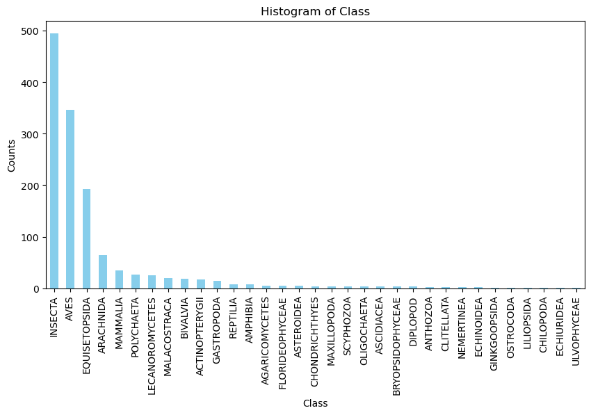

```python
import matplotlib.pyplot as plt

# Assuming 'data' is your DataFrame
class_counts = merged_cleaned['class'].value_counts()

plt.figure(figsize=(10, 5))
class_counts.plot(kind='bar', color='skyblue')
plt.title('Histogram of Class')
plt.xlabel('Class')
plt.ylabel('Counts')
plt.xticks(rotation=90)
plt.show()
```

## Pie Chart of all the Phylum

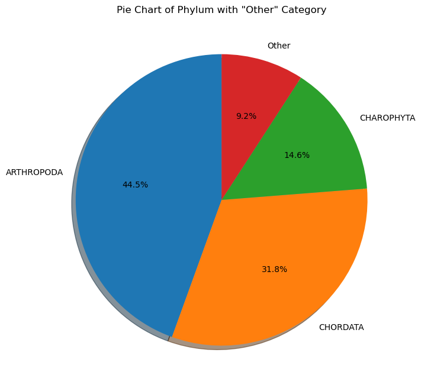

```python
# Calculate the value counts for the 'phylum' column
phylum_counts = merged_cleaned['phylum'].value_counts()

# Define a threshold for 'Other' category. You can adjust the threshold as needed.
threshold_percent = 5  # Percentage considered as 'Other'
other_threshold = sum(phylum_counts) * (threshold_percent / 100)

# Combine smaller categories into 'Other'
other = phylum_counts[phylum_counts < other_threshold].sum()
main_phylum_counts = phylum_counts[phylum_counts >= other_threshold]
main_phylum_counts['Other'] = other

# Create a pie chart
plt.figure(figsize=(8, 8))
plt.pie(main_phylum_counts, labels=main_phylum_counts.index, autopct='%1.1f%%', shadow=True, startangle=90)
plt.title('Pie Chart of Phylum with "Other" Category')
plt.show()
```

## Splitting geopoint column into lat an long

```python
# Function to safely extract longitude and latitude
def extract_lat_lon(geopoint):
    if isinstance(geopoint, str):
        try:
            geopoint = eval(geopoint)  # Convert string to dict
        except:
            return None, None  # Return None if eval fails
    # Check if the dictionary has 'lat' and 'lon' keys
    if isinstance(geopoint, dict) and 'lon' in geopoint and 'lat' in geopoint:
        return geopoint['lat'], geopoint['lon']
    else:
        return None, None  # Return None if keys are not present

# Apply the function to the 'geopoint' column
merged_cleaned[['latitude', 'longitude']] = merged_cleaned['geopoint'].apply(extract_lat_lon).apply(pd.Series)

# Show the head of the DataFrame to confirm the new columns
print(merged_cleaned.head())
```

```
     taxa   kingdom      phylum    class    order   family    genus  species  \
3  Insect  ANIMALIA  ARTHROPODA  INSECTA  Unknown  Unknown  Unknown  Unknown
4  Insect  ANIMALIA  ARTHROPODA  INSECTA  Unknown  Unknown  Unknown  Unknown
5  Insect  ANIMALIA  ARTHROPODA  INSECTA  Unknown  Unknown  Unknown  Unknown
6  Insect  ANIMALIA  ARTHROPODA  INSECTA  Unknown  Unknown  Unknown  Unknown
7  Insect  ANIMALIA  ARTHROPODA  INSECTA  Unknown  Unknown  Unknown  Unknown

  common_name                            geopoint  latitude  longitude
3     Unknown  {'lon': 144.9748, 'lat': -37.8185}  -37.8185   144.9748
4     Unknown  {'lon': 144.9634, 'lat': -37.7908}  -37.7908   144.9634
5     Unknown  {'lon': 144.9706, 'lat': -37.8216}  -37.8216   144.9706
6     Unknown  {'lon': 144.9606, 'lat': -37.7986}  -37.7986   144.9606
7     Unknown  {'lon': 144.9564, 'lat': -37.7918}  -37.7918   144.9564
```

```python
# Drop the original 'geopoint' column
merged_cleaned.drop(columns=['geopoint'], inplace=True)
```

# Taxa Distribution

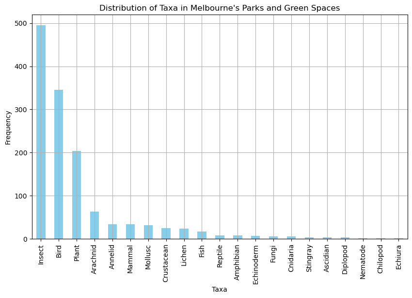

```python
# Plot a histogram for the distribution of different taxa
plt.figure(figsize=(10, 6))
merged_cleaned['taxa'].value_counts().plot(kind='bar', color='skyblue')
plt.title('Distribution of Taxa in Melbourne\'s Parks and Green Spaces')
plt.xlabel('Taxa')
plt.ylabel('Frequency')
plt.xticks(rotation=90)
plt.grid(True)
plt.show()
```

# Inspect dataset for taxa

```python
import folium

# Assuming you've already cleaned and prepared 'merged_cleaned' DataFrame
melbourne_coordinates = [-37.814, 144.96332]

# Create a Folium map centered around Melbourne
m = folium.Map(location=melbourne_coordinates, zoom_start=12)

# Print unique taxa
unique_taxa = merged_cleaned['taxa'].unique()
print("Unique Taxa in the Dataset:")
print(unique_taxa)

# Define a color mapping for different taxa
taxa_mapping = {
    'Mollusc': {'color': 'green', 'icon': 'glyphicon-leaf'},
    'Insect': {'color': 'red', 'icon': 'glyphicon-bug'},
    'Bird': {'color': 'blue', 'icon': 'glyphicon-bird'},
    'Mammal': {'color': 'gray', 'icon': 'glyphicon-knight'},
    # Add other taxa and customize icons as needed
}

# Loop through each row in the DataFrame to add markers, ensuring no NaN coordinates
for _, row in merged_cleaned.dropna(subset=['latitude', 'longitude']).iterrows():
    lat, lng = row['latitude'], row['longitude']
    taxa = row['taxa']
    if taxa in taxa_mapping:
        marker_color = taxa_mapping[taxa]['color']
        marker_icon = taxa_mapping[taxa]['icon']
    else:
        marker_color = 'purple'  # default color
        marker_icon = 'glyphicon-question-sign'  # default icon

    # Add markers to the map
    folium.Marker(
        location=[lat, lng],
        popup=f"{taxa} - {row['common_name']}",
        icon=folium.Icon(color=marker_color, icon=marker_icon)
    ).add_to(m)

# Display the map
m
```

```
Unique Taxa in the Dataset:
['Insect' 'Annelid' 'Amphibian' 'Arachnid' 'Plant' 'Stingray' 'Bird'
 'Fungi' 'Cnidaria' 'Crustacean' 'Diplopod' 'Echinoderm' 'Fish' 'Mollusc'
 'Lichen' 'Mammal' 'Reptile' 'Ascidian' 'Nematode' 'Chilopod' 'Echiura']
```

Make this Notebook Trusted to load map: File -> Trust Notebook

[interactive chart not shown]

## Focusing only on bats

Chiroptera is the name of the order of the only mammal capable of true flight, the bat. The name is influenced by the hand-like wings of bats, which are formed from four elongated "fingers" covered by a cutaneous membrane.

Vespertilionidae is a family of microbats, of the order Chiroptera, flying, insect-eating mammals variously described as the common, vesper, or simple nosed bats.

```python
merged_cleaned
```

|  | taxa | kingdom | phylum | class | order | family | genus | species | common_name | latitude | longitude |
| --- | --- | --- | --- | --- | --- | --- | --- | --- | --- | --- | --- |
| 3 | Insect | ANIMALIA | ARTHROPODA | INSECTA | Unknown | Unknown | Unknown | Unknown | Unknown | -37.8185 | 144.9748 |
| 4 | Insect | ANIMALIA | ARTHROPODA | INSECTA | Unknown | Unknown | Unknown | Unknown | Unknown | -37.7908 | 144.9634 |
| 5 | Insect | ANIMALIA | ARTHROPODA | INSECTA | Unknown | Unknown | Unknown | Unknown | Unknown | -37.8216 | 144.9706 |
| 6 | Insect | ANIMALIA | ARTHROPODA | INSECTA | Unknown | Unknown | Unknown | Unknown | Unknown | -37.7986 | 144.9606 |
| 7 | Insect | ANIMALIA | ARTHROPODA | INSECTA | Unknown | Unknown | Unknown | Unknown | Unknown | -37.7918 | 144.9564 |
| ... | ... | ... | ... | ... | ... | ... | ... | ... | ... | ... | ... |
| 1359 | Mammal | ANIMALIA | CHORDATA | MAMMALIA | CHIROPTERA | MOLOSSIDAE | Mormopterus | None | None | -37.8135 | 144.9786 |
| 1360 | Mammal | ANIMALIA | CHORDATA | MAMMALIA | CHIROPTERA | VESPERTILIONIDAE | Myotis | macropus | Large-footed Myotis | -37.8312 | 144.9804 |
| 1361 | Mammal | ANIMALIA | CHORDATA | MAMMALIA | VESPERTILIONIDAE | MOLOSSIDAE | Scotorepens | None | None | -37.8312 | 144.9804 |
| 1362 | Mammal | ANIMALIA | CHORDATA | MAMMALIA | VESPERTILIONIDAE | MOLOSSIDAE | Scotorepens | None | None | -37.8135 | 144.9786 |
| 1363 | Mammal | ANIMALIA | CHORDATA | MAMMALIA | CHIROPTERA | VEPSERTILIONIDAE | Nyctophilus | None | None | -37.8312 | 144.9804 |

1322 rows × 11 columns

```python
# Check for NaN values in latitude and longitude
nan_latitude = merged_cleaned['latitude'].isna().sum()
nan_longitude = merged_cleaned['longitude'].isna().sum()
print(f"Number of NaN values in latitude: {nan_latitude}")
print(f"Number of NaN values in longitude: {nan_longitude}")
```

```
Number of NaN values in latitude: 0
Number of NaN values in longitude: 0
```

## Mapping of bats based on their unique locations

```python
# Filter for entries where the order is either 'CHIROPTERA' or 'VESPERTILIONIDAE'
bats_data = merged_cleaned[
    merged_cleaned['order'].str.upper().isin(['CHIROPTERA', 'VESPERTILIONIDAE'])
]

# Summary of the filtered data
print("Summary of Bat Observations:")
print(f"Total records: {bats_data.shape[0]}")
print(f"Unique species: {bats_data['species'].nunique()}")
common_species = bats_data['species'].mode().values
print(f"Common species: {common_species if common_species.size > 0 else 'None'}")
print(f"Unique locations: {bats_data[['latitude', 'longitude']].dropna().drop_duplicates().shape[0]}")

# Create a map centered around the approximate locations of the bat observations
bat_map = folium.Map(location=[-37.8311, 144.9452], zoom_start=12)

# Add markers for each bat observation
for idx, row in bats_data.dropna(subset=['latitude', 'longitude']).iterrows():
    species_info = f"{row['genus']} {row['species']} - {row['common_name']}"
    folium.Marker(
        location=[row['latitude'], row['longitude']],
        popup=species_info,
        icon=folium.Icon(color='red', icon='glyphicon-tint')
    ).add_to(bat_map)

# Display the map directly in Jupyter (optional)
bat_map
```

```
Summary of Bat Observations:
Total records: 17
Unique species: 5
Common species: ['poliocephalus']
Unique locations: 7
```

Make this Notebook Trusted to load map: File -> Trust Notebook

[interactive chart not shown]

## Piechart of bat species distribution

The pie chart of bat species distribution visualizes the relative frequencies of different bat species in the dataset. Each slice of the pie chart represents a specific species, with the size of the slice corresponding to the proportion of observations of that species in comparison to the total observations across all species.

- Quantitative Comparison: This chart provides a quick and easy way to compare how common each bat species is within the studied area. Larger slices indicate more commonly observed species, while smaller slices represent less frequent ones.
- Diversity Insight: It helps in understanding the biodiversity of bats in the region by showing the variety of species and their relative abundance.
- Conservation Priorities: For conservation efforts, knowing which species are more or less common can help prioritize actions, especially if some of the less common species are also known to be at risk.

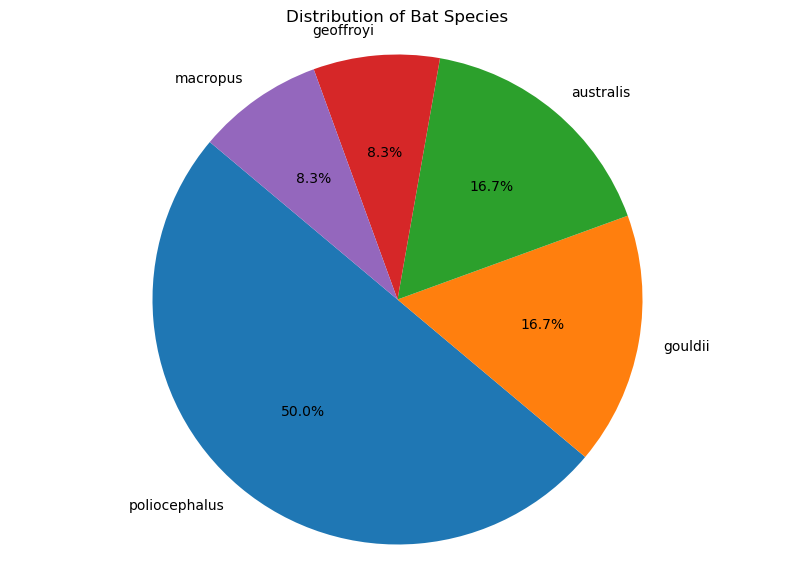

```python
# Ensure the species column does not have too many unique categories
species_counts = bats_data['species'].value_counts()
top_species = species_counts.head(10)  # You can adjust to include more species if needed

# Create a pie chart
plt.figure(figsize=(10, 7))
plt.pie(top_species, labels=top_species.index, autopct='%1.1f%%', startangle=140)
plt.title('Distribution of Bat Species')
plt.axis('equal')  # Equal aspect ratio ensures that pie is drawn as a circle.
plt.show()
```

Species richness refers to the number of different species present in a given ecological community, region, or habitat. It is a measure of biodiversity that does not account for the abundance of species, only their presence.

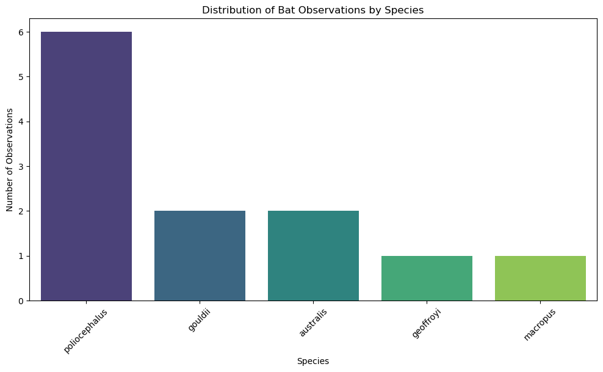

```
Species Richness: 5
```

```python
import matplotlib.pyplot as plt
import seaborn as sns

# Calculate species richness (number of unique species)
species_richness = bats_data['species'].nunique()

# Calculate the distribution of observations per species
species_distribution = bats_data['species'].value_counts()

# Plot the distribution of observations per species
plt.figure(figsize=(12, 6))
sns.barplot(x=species_distribution.index, y=species_distribution.values, palette="viridis")
plt.title('Distribution of Bat Observations by Species')
plt.xlabel('Species')
plt.ylabel('Number of Observations')
plt.xticks(rotation=45)
plt.show()

print(f"Species Richness: {species_richness}")
```

## Heatmap

The intensity of colors illustrates the density of bat observations across different geographic regions or shows correlations between various environmental factors such as temperature and bat activity. By displaying data on a color gradient, heatmaps allow researchers and conservationists to quickly identify hotspots of bat activity, understand habitat preferences, and discern patterns that may influence bat behavior.

```python
from folium.plugins import HeatMap

# Create a map centered around the approximate locations of the bat observations
heat_map = folium.Map(location=[-37.8311, 144.9452], zoom_start=12)

# Add a heat map layer
heat_data = [[ row['latitude'], row['longitude']] for index, row in bats_data.dropna(subset=['latitude', 'longitude']).iterrows()]
HeatMap(heat_data).add_to(heat_map)

# Display the map directly in Jupyter (optional)
heat_map
```

Make this Notebook Trusted to load map: File -> Trust Notebook

[interactive chart not shown]

# Clustering the Bat data

```python
from folium.plugins import MarkerCluster

# Create a map centered around the average coordinates
bat_map = folium.Map(location=[bats_data['latitude'].mean(), bats_data['longitude'].mean()], zoom_start=12)

# Create a marker cluster
marker_cluster = MarkerCluster().add_to(bat_map)

# Add markers to the cluster instead of the map
for idx, row in bats_data.dropna(subset=['latitude', 'longitude']).iterrows():
    species_info = f"{row['genus']} {row['species']} - {row['common_name']}"
    folium.Marker(
        location=[row['latitude'], row['longitude']],
        popup=species_info,
        icon=folium.Icon(color='red', icon='glyphicon-tint')
    ).add_to(marker_cluster)

# display the map
bat_map
```

Make this Notebook Trusted to load map: File -> Trust Notebook

[interactive chart not shown]

# Butterfly Biodiversity

```python
butterfly
```

|  | site | sloc | walk | sighting_date | time | vegwalktime | vegspecies | vegfamily | latitude | longitude | ... | tabe | brow | csem | aand | jvil | paur | ogyr | gmac | datetime | geopoint |
| --- | --- | --- | --- | --- | --- | --- | --- | --- | --- | --- | --- | --- | --- | --- | --- | --- | --- | --- | --- | --- | --- |
| 0 | Womens Peace Gardens | 2 | 1 | 2017-02-26 | 11:42:00 | 1.3128 | Schinus molle | Anacardiaceae | -37.7912 | 144.9244 | ... | 0 | 0 | 0 | 0 | 0 | 0 | 0 | 0 | 2017-02-26 11:42:00+00:00 | -37.7912, 144.9244 |
| 1 | Argyle Square | 1 | 1 | 2017-11-02 | 10:30:00 | 0.3051 | Rosmarinus officinalis | Lamiaceae | -37.8023 | 144.9665 | ... | 0 | 0 | 0 | 0 | 0 | 0 | 0 | 0 | 2017-02-11 10:30:00+00:00 | -37.8023, 144.9665 |
| 2 | Argyle Square | 2 | 1 | 2017-12-01 | 10:35:00 | 0.3620 | Euphorbia sp. | Euphorbiaceae | -37.8026 | 144.9665 | ... | 0 | 0 | 0 | 0 | 0 | 0 | 0 | 0 | 2017-01-12 10:35:00+00:00 | -37.8026, 144.9665 |
| 3 | Westgate Park | 4 | 1 | 2017-03-03 | 11:44:00 | 3.1585 | Melaleuca lanceolata | Myrtaceae | -37.8316 | 144.9089 | ... | 0 | 0 | 0 | 0 | 0 | 0 | 0 | 0 | 2017-03-03 11:44:00+00:00 | -37.8316, 144.9089 |
| 4 | Argyle Square | 1 | 3 | 2017-01-15 | 12:33:00 | 0.4432 | Mentha sp. | Lamiaceae | -37.8027 | 144.9662 | ... | 0 | 0 | 0 | 0 | 0 | 0 | 0 | 0 | 2017-01-15 12:33:00+00:00 | -37.8027, 144.9662 |
| ... | ... | ... | ... | ... | ... | ... | ... | ... | ... | ... | ... | ... | ... | ... | ... | ... | ... | ... | ... | ... | ... |
| 4051 | Fitzroy-Treasury Gardens | 3 | 2 | 2017-06-02 | 17:44:00 | 0.5132 | Tagetes sp. | Asteraceae | -37.8136 | 144.9819 | ... | 0 | 0 | 0 | 0 | 0 | 0 | 0 | 0 | 2017-02-06 17:44:00+00:00 | -37.8136, 144.9819 |
| 4052 | Westgate Park | 4 | 2 | 2017-02-02 | 13:57:00 | 2.1947 | Myoporum parvifolium | Scrophulariaceae | -37.8311 | 144.9092 | ... | 0 | 0 | 0 | 0 | 0 | 0 | 0 | 0 | 2017-02-02 13:57:00+00:00 | -37.8311, 144.9092 |
| 4053 | Westgate Park | 5 | 3 | 2017-06-03 | 15:43:00 | 4.2408 | Cassinia arcuata | Asteraceae | -37.8299 | 144.9106 | ... | 0 | 0 | 0 | 0 | 0 | 0 | 0 | 0 | 2017-03-06 15:43:00+00:00 | -37.8299, 144.9106 |
| 4054 | Westgate Park | 4 | 1 | 2017-02-02 | 11:05:00 | 1.5948 | Xerochrysum viscosum | Asteraceae | -37.8316 | 144.9093 | ... | 0 | 0 | 0 | 0 | 0 | 0 | 0 | 0 | 2017-02-02 11:05:00+00:00 | -37.8316, 144.9093 |
| 4055 | Carlton Gardens South | 3 | 1 | 2017-01-30 | 12:42:00 | 1.4437 | Asteraceae 1 | Asteraceae | -37.8044 | 144.9704 | ... | 0 | 0 | 0 | 0 | 0 | 0 | 0 | 0 | 2017-01-30 12:42:00+00:00 | -37.8044, 144.9704 |

4056 rows × 42 columns

# Number of unique family and species

```python
# Calculate the number of unique species
unique_species = butterfly['vegspecies'].nunique()

# Calculate the number of unique families
unique_families = butterfly['vegfamily'].nunique()

print(f"Number of unique vegetation species: {unique_species}")
print(f"Number of unique vegetation families: {unique_families}")
```

```
Number of unique vegetation species: 134
Number of unique vegetation families: 59
```

# Summary of the number of sightings at each site

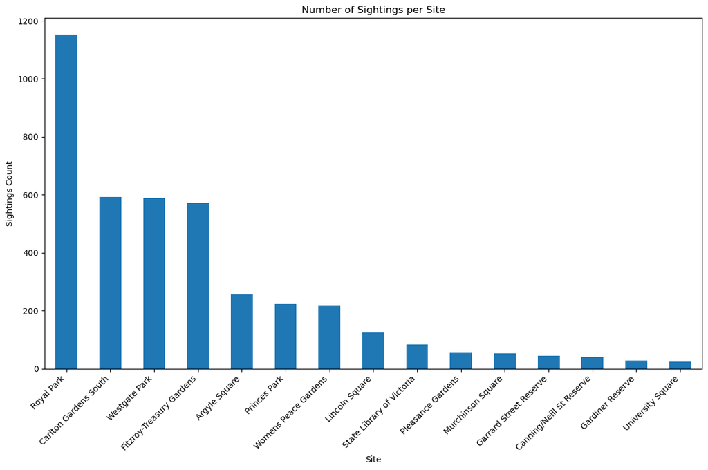

```python
# Count the number of sightings at each site
sightings_per_site = butterfly['site'].value_counts()

# Bar plot of the number of sightings per site
plt.figure(figsize=(12, 8))
sightings_per_site.plot(kind='bar')
plt.title('Number of Sightings per Site')
plt.xlabel('Site')
plt.ylabel('Sightings Count')
plt.xticks(rotation=45, ha='right')  # Rotate the x labels for better readability
plt.tight_layout()  # Adjust layout
plt.show()
```

# Average temperature and humidity of each site

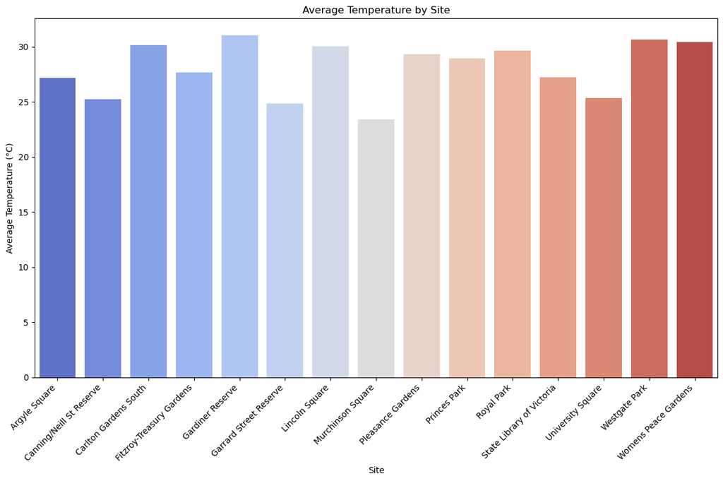

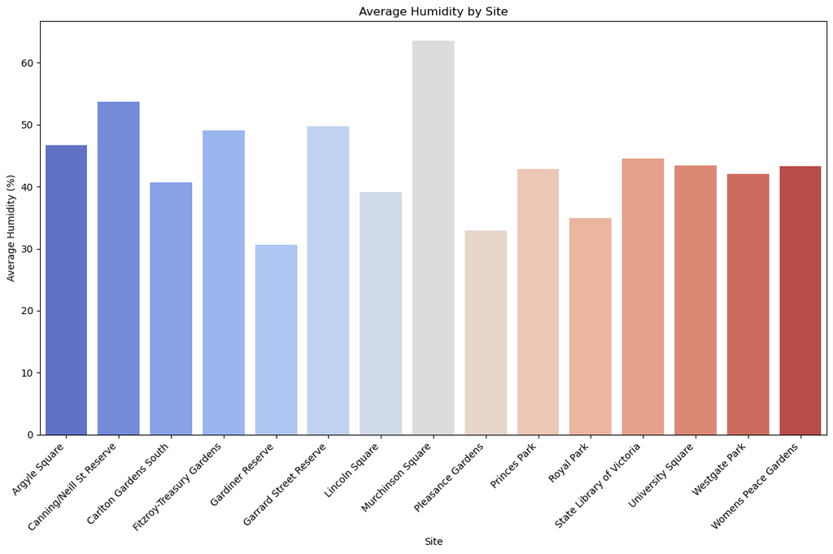

```python
# We first group the data by 'site' and calculate the mean for the 'temp' and 'hum' columns
site_comparison = butterfly.groupby('site').agg({'temp':'mean', 'hum':'mean'}).reset_index()

# Now let's create a bar plot for average temperature by site
plt.figure(figsize=(12, 8))
sns.barplot(x='site', y='temp', data=site_comparison, palette='coolwarm')
plt.title('Average Temperature by Site')
plt.xlabel('Site')
plt.ylabel('Average Temperature (°C)')
plt.xticks(rotation=45, ha='right')  # Rotate the x labels for better readability
plt.tight_layout()  # Adjust layout
plt.show()

# And a bar plot for average humidity by site
plt.figure(figsize=(12, 8))
sns.barplot(x='site', y='hum', data=site_comparison, palette='coolwarm')
plt.title('Average Humidity by Site')
plt.xlabel('Site')
plt.ylabel('Average Humidity (%)')
plt.xticks(rotation=45, ha='right')  # Rotate the x labels for better readability
plt.tight_layout()  # Adjust layout
plt.show()
```